# Midterm Examination

Sean Schilk

3/8/26

```r
data <- c(17.3, 24.8, 8.2, 31.5, 14.1, 42.7, 11.9, 55.3, 21.4, 9.7, 36.2, 18.6, 63.1, 13.2, 28.9, 47.5, 19.8, 7.5, 33.4, 52.1, 16.0, 25.9, 38.7, 10.3, 44.2, 22.5, 58.6, 12.8, 30.3, 48.9, 20.1, 35.4, 15.7, 60.2, 26.7, 41.3, 18.1, 53.8, 23.9, 46.2, 29.4, 37.6, 14.9, 50.5, 32.8, 19.3, 56.7, 11.2, 39.5, 27.1)
```

## **Question 1**: Method of Moments Estimation (MME) of $\mu$ and $\sigma^2$

Estimate the parameters $\mu$ and $\sigma^2$ (*caution: not $\sigma$!*) from the raw oil reserve data using the given $k$-th moment function. Organize your work into three parts:

1. Derive the system of two equations for the method of moments estimators (MMEs) of $\mu$ and $\sigma^2$.
2. Derive the closed-form expressions for the MMEs of $\mu$, $\sigma^2$, and $\mu_{LN}$, denoted by $\widetilde{\mu}$, $\widetilde{\sigma^2}$, and $\widetilde{\mu_{LN}}$, respectively.

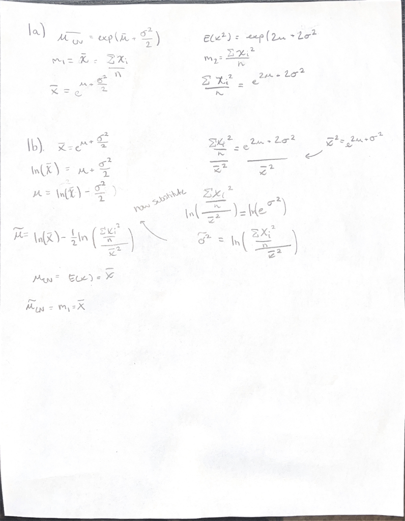

```r
knitr::include_graphics("https://sschilk.github.io/Mathematical-Statistics-II/Midterm/a.b.jpeg")
```

3. Write an R function that outputs the MMEs $\widetilde{\mu}$, $\widetilde{\sigma^2}$, and $\widetilde{\mu_{LN}}$ based on the given data set.

```r
lognormal_mme <- function(data){
  m1 <- mean(data)
  m2 <- mean(data^2)

sigma_2_mme <- log(m2) - 2*log(m1)

mu_mme <- log(m1) - 1/2 * sigma_2_mme

mu_ln_mme <- exp(mu_mme + 1/2 * sigma_2_mme)

return(c(mu_mme, sigma_2_mme, mu_ln_mme))
}

lognormal_mme(data)
```

```
[1]  3.3012685  0.2339652 30.5160000
```

## **Question 2**: Finding the MLE of $\mu$ and $\sigma^2$

This question involves two parts:

(1). Derive the score functions (i.e., the gradient of the log-likelihood) for the parameters of the log-normal distribution, and set them to zero to obtain the system of score equations. Begin with the full log-likelihood and compute its partial derivatives with respect to $\mu$ and $\sigma^2$. [Hint: letting $\beta = \sigma^2$ may simplify differentiation.]

Assume that $\{x_1, x_2, \cdots, x_n \} \to \text{ LN }(\mu, \sigma^2)$ with density function given by

$$\ell(\mu, \sigma^2) = -\frac{n}{2} \ln(2\pi) - n \ln \sigma -
\sum_{i=1}^n \ln x_i
- \frac{1}{2\sigma^2} \sum_{i=1}^n (\ln x_i - \mu)^2$$

(2). Perform some algebra to find the closed form of the MLE of $\mu$ and $\sigma^2$, denoted by $\widehat{\mu}$ and $\widehat{\sigma^2}$.

(3). Recall that lognormal population mean (i.e., the first moment) is

$$\mu_{LN} = \mathbb{E}[X] = \exp\left( \mu + \frac{1}{2} \sigma^2
\right).$$

Using the relationship between variance and the first and second moments, $\text{Var}(X) = \mathbb{E}[X^2] - \left(\mathbb{E}[X]\right)^2$, we derive the population variance of the lognormal distribution, denoted as $\sigma_{\text{LN}}^2$. This result will be used in applying the Central Limit Theorem in subsequent questions

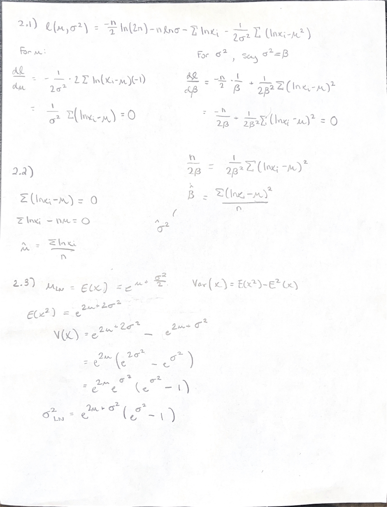

```r
knitr::include_graphics("https://sschilk.github.io/Mathematical-Statistics-II/Midterm/Question2.jpeg")
```

## **Question 3**: Sampling Distribution of Lognormal **Sample Mean** $\widehat{\mu_{LN}}$

We have derived two different estimators of lognormal population mean $\mu_{LN}$. This Question focuses on the sampling distribution of lognormal sample sample means based on MLE. The following are detailed instructions.

(1). Write an R function to estimate the MLE of $\mu$ and $\sigma^2$, denoted by $\widehat{\mu}$ and $\widehat{\sigma^2}$ and return the MLE of $\mu_{LN}$, denoted by $\widehat{\mu_{LN}}$.

```r
lognormal_mle <- function(data){
  n <- length(data)

  mu_mle <- sum(log(data)) / n
  sigma_2_mle <- sum((log(data) - mu_mle)^2) / n

  mu_ln <- exp(mu_mle + 1/2 * sigma_2_mle)
  return(mu_ln)
}
lognormal_mle(data) # return mu_ln mle
```

```
[1] 30.94264
```

(2). Take 1000 Bootstrap samples from the raw oil data set. For each bootstrap sample, call the above R function to find the **bootstrap MLE** of $\mu_{LN}$, denoted by $\widehat{\mu_{LN}^*}^{(1)}, \widehat{\mu_{LN}^*}^{(2)}, \cdots, \widehat{\mu_{LN}^*}^{(1000)}$.

```r
set.seed(1)
bt.sample.mu.ln.mle = NULL

#Bootstrap
for(i in 1:1000){
  ith.bt.sample = sample(x = data,
                       size = 50,
                    replace = TRUE
                       )
mu.ln.mle.star <- lognormal_mle(ith.bt.sample)

bt.sample.mu.ln.mle[i] = mu.ln.mle.star

}
```

(3). Using kernel density estimation approach to estimate the bootstrap density curves based on the bootstrap MLEs: $\widehat{\mu_{LN}^*}^{(1)}, \widehat{\mu_{LN}^*}^{(2)}, \cdots, \widehat{\mu_{LN}^*}^{(1000)}$.

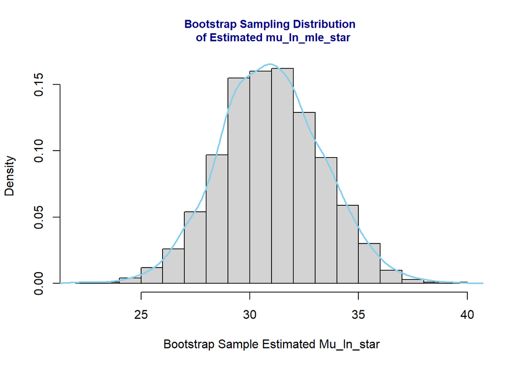

```r
hist(bt.sample.mu.ln.mle,
     breaks = 14,
     probability = TRUE,
       xlab = "Bootstrap Sample Estimated Mu_ln_star",
        main="Bootstrap Sampling Distribution \n of Estimated mu_ln_mle_star",
          cex.main = 0.9,
       col.main = "navy")
lines(density(bt.sample.mu.ln.mle), col = "skyblue", lwd = 2) # KDE
```

(4). In order to find the asymptotic sampling distribution using the **central limit theorem (CLT)**. That is, when sample size is large,

$$\bar{X} \to N \left(\mu_{LN}, \frac{\sigma_{LN}}{\sqrt{n}}\right)$$

where $\mu_{LN}$ and $\sigma_{LN}$ can be estimated by using the **plug-in principle of MLE**. Based on the asymptotic sampling distribution of **lognormal sample mean** $\bar{X}$, add the asymptotic density curve to the above Bootstrap kernel density curve.

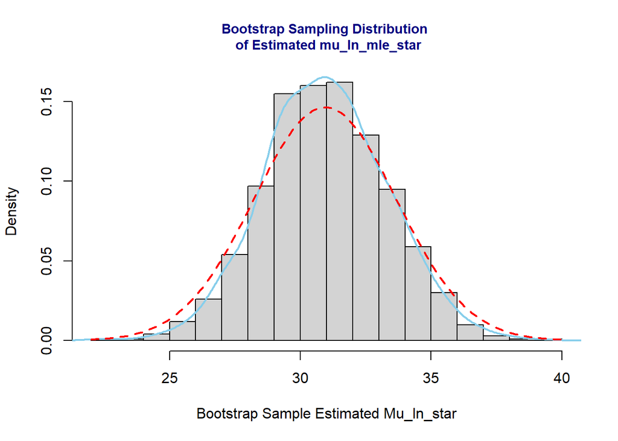

```r
n <- length(data)
# Run these BEFORE plotting
mu.hat        <- mean(log(data))
sigma2.hat    <- mean((log(data) - mu.hat)^2)      # MLE uses 1/n

mu.LN.hat     <- exp(mu.hat + sigma2.hat / 2)
sigma2.LN.hat <- exp(2*mu.hat + sigma2.hat) * (exp(sigma2.hat) - 1)
se.xbar       <- sqrt(sigma2.LN.hat / n)

# original plot
hist(bt.sample.mu.ln.mle,
     breaks = 14,
     probability = TRUE,
       xlab = "Bootstrap Sample Estimated Mu_ln_star",
        main="Bootstrap Sampling Distribution \n of Estimated mu_ln_mle_star",
          cex.main = 0.9,
       col.main = "navy")
lines(density(bt.sample.mu.ln.mle), col = "skyblue", lwd = 2) # KDE
# add ASD
curve(dnorm(x, mean = mu.LN.hat, sd = se.xbar),                # CLT asymptotic
      col = "red", lwd = 2, lty = 2, add = TRUE)
```

(5). Write a short summary to compare the two sampling distributions of the sample mean of the lognormal distribution.

Bootstrap sampling is the process of taking repeated samples from the data set to approximate, in this case, our population mean through the given data. Using CLT, with the assumption of a large n, approximates the sample mean is normal. Then we estimate that sample mean using MLE. So the difference here is that bootstrap gives estimates off of observed data, while CLT uses theoretical equations to predict our estimates. I would recommend bootstrap given our data set doesn’t have a large n.